# Reproducible Research: Peer Assessment 1

## Loading and preprocessing the data

### Loading

Unzip and load `activity.csv`.

```r
unzip("activity.zip")
activity <- read.csv("activity.csv")
```

### Preprocessing

Initially, the date column is loaded as Factors. We need to convert the date column to dates.

```r
activity$date <- as.Date(activity$date, format = "%Y-%m-%d")
```

## What is mean total number of steps taken per day?

### Histogram of total number of steps taken each day

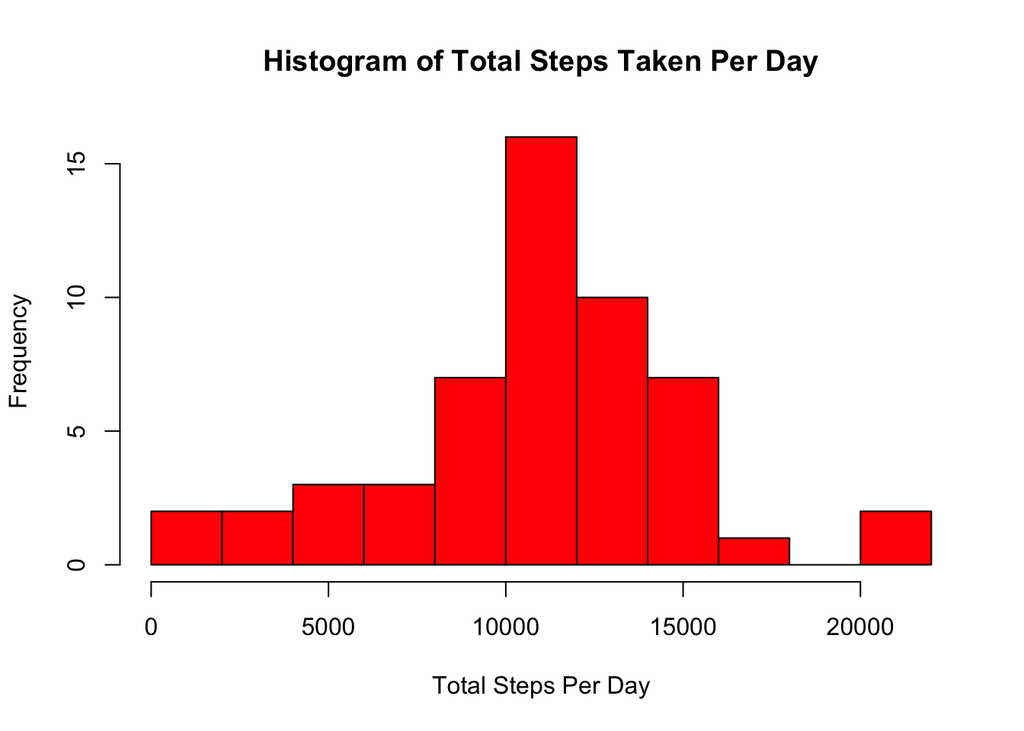

```r
totalSteps <- aggregate(steps ~ date, data=activity, sum, na.rm=TRUE)
hist(totalSteps$steps, col="red", xlab="Total Steps Per Day", ylab="Frequency",  main="Histogram of Total Steps Taken Per Day", breaks=10)
```

### Mean and median of total number of steps taken per day

```r
meanTotSteps <- mean(totalSteps$steps, na.rm=TRUE)
medianTotSteps <- median(totalSteps$steps, na.rm=TRUE)
```

The mean total number of steps is 1.0766 × 10<sup>4</sup> and the median total number of steps is 10765.

## What is the average daily activity pattern?

### Time series plot of the 5-minute interval (x-axis) and the average number of steps taken, averaged across all days (y-axis)

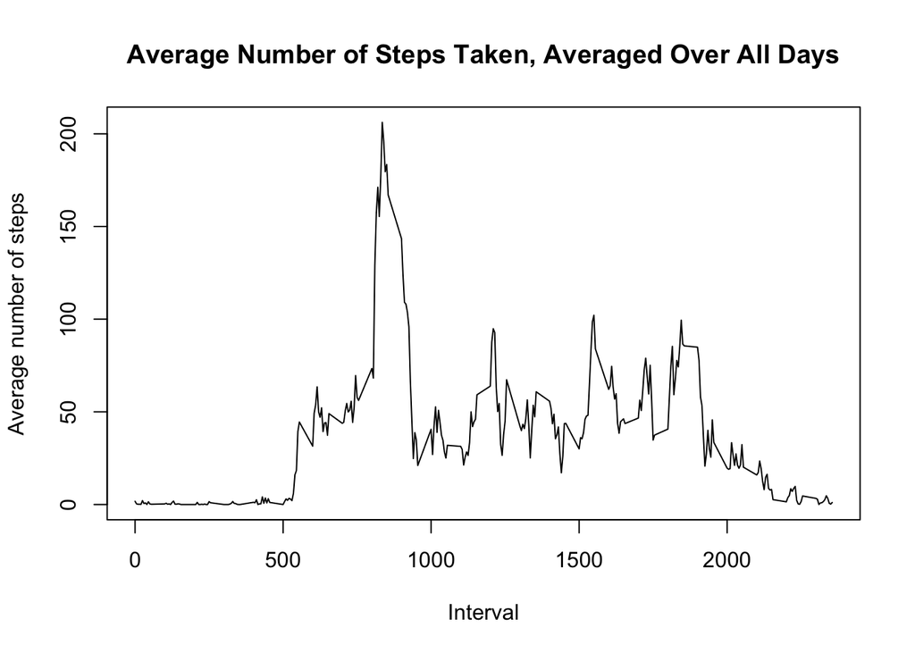

```r
intervalSteps <- aggregate(steps ~ interval, activity, mean, na.rm=TRUE)
plot(intervalSteps$interval, intervalSteps$steps, type='l', col=1,
     main="Average Number of Steps Taken, Averaged Over All Days", xlab="Interval",
     ylab="Average number of steps")
```

### The 5-minute interval, on average across all the days in the dataset, that contains the maximum number of steps

```r
maxIntervalStepsIndex <- which.max(intervalSteps$steps)
intervalWithMaxSteps <- intervalSteps[maxIntervalStepsIndex, "interval"]
maxSteps <- intervalSteps[maxIntervalStepsIndex, "steps"]
```

Interval 835 contains the maximum number of steps, 206.1698.

## Imputing missing values

### Total number of missing values in the dataset

```r
missingValuesCount <- sum(is.na(activity))
```

There are 2304 missing values in the dataset.

### Use median steps per interval to fill in missing values

```r
# create dataframe with median steps per interval
medianStepsPerInterval <- aggregate(activity$steps, by=list(activity$interval), median, na.rm=TRUE)
names(medianStepsPerInterval)[1] <- "interval"
names(medianStepsPerInterval)[2] <- "medianSteps"

# merge activity and medianStepsPerInterval
missing <- merge(activity, medianStepsPerInterval, by="interval", sort=FALSE)

# sort on date and interval
missing <- missing[with(missing, order(date, interval)), ]

# replace NA in steps column with value in medianSteps column
missing$steps[is.na(missing$steps)] <- missing$medianSteps[is.na(missing$steps)]

# remove medianSteps column
missing$medianSteps <- NULL

# missing values are now filled with median
newActivity <- missing[, c(2, 3, 1)]
head(newActivity)
```

```
##     steps       date interval
## 1       0 2012-10-01        0
## 63      0 2012-10-01        5
## 128     0 2012-10-01       10
## 205     0 2012-10-01       15
## 264     0 2012-10-01       20
## 327     0 2012-10-01       25
```

### Histogram of the total number of steps taken each day from imputed steps using median

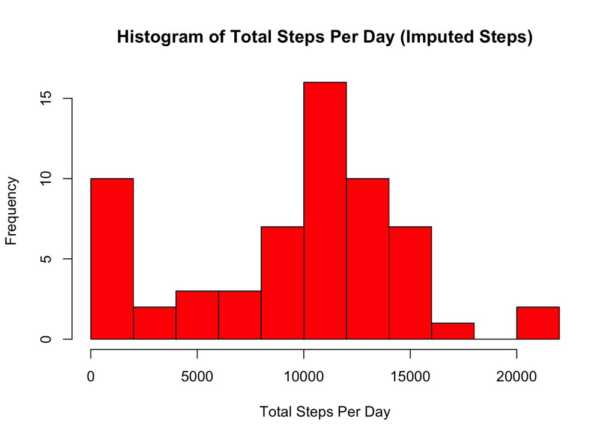

```r
totalImpSteps <- aggregate(newActivity$steps, by=list(newActivity$date), sum)
names(totalImpSteps)[1] <- "day"
names(totalImpSteps)[2] <- "steps"

hist(totalImpSteps$steps, col="red", main="Histogram of Total Steps Per Day (Imputed Steps)",
    xlab="Total Steps Per Day", breaks=10)
```

### Mean and median of total number of steps taken per day from imputed steps using median

```r
meanTotImpSteps <- mean(totalImpSteps$steps, na.rm=TRUE)
medianTotImpSteps <- median(totalImpSteps$steps, na.rm=TRUE)
```

The mean total number of steps is 9503.8689 and the median total number of steps is 10395.

## Are there differences in activity patterns between weekdays and weekends?

### Create a new factor variable in the dataset with two levels – “weekday” and “weekend”

```r
# create a factor with the names of the days for all dates
newActivity$weekdays <- factor(format(newActivity$date, "%A"))
# the day names
levels(newActivity$weekdays)
```

```
## [1] "Friday"    "Monday"    "Saturday"  "Sunday"    "Thursday"  "Tuesday"
## [7] "Wednesday"
```

```r
# replace the levels
levels(newActivity$weekdays) <- list(weekday=c("Monday", "Tuesday", "Wednesday",
    "Thursday", "Friday"), weekend=c("Saturday", "Sunday"))
```

### Time series plot of the 5-minute interval vs. the average number of steps taken, averaged across all weekday days or weekend days.

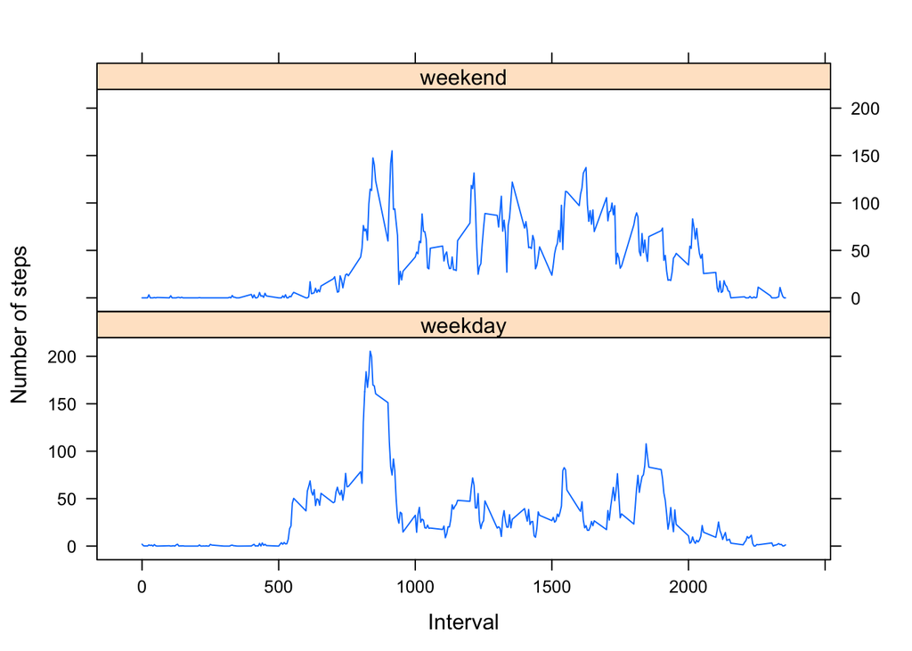

```r
stepsMeanInterval <- aggregate(newActivity$steps, by=list(newActivity$weekdays, newActivity$interval), mean, na.rm=TRUE, na.action=NULL)
names(stepsMeanInterval)[1] <- "weekday"
names(stepsMeanInterval)[2] <- "interval"
names(stepsMeanInterval)[3] <- "meanSteps"

library(lattice)
xyplot(stepsMeanInterval$meanSteps ~ stepsMeanInterval$interval |
    stepsMeanInterval$weekday, layout = c(1, 2), type = "l", xlab = "Interval",
    ylab = "Number of steps")
```